# Eco Topic 1 Individual Report

Big Data in Ecology

Author

Mikaely Evans

# README

EcoTopic1 is a group project completed by Mikaely Evans, Georgia Akins, and Seth Lorenzen that analyzes United States Geological Survey data to visualize nutrient uptake in two rivers in the United States. Data from a rural river (Cedar River) in Iowa and an urban river (East Fork River) in Indiana were used to visualize the effects of land use on nutrient uptake. This data was collected over a one week period in July of 2019 using sensors to track Nitrate Concentration, Dissolved Oxygen, and Discharge Rate of the river every 15 minutes. Link to the data: “USGS_CedarRiver_IA_2019.txt”, “USGS_IN_EastFork_July2019.txt”

# Introduction

Rivers provide high ecological value to the ecosystems they occupy. They provide habitat for aquatic flora and fauna, hydration for plants and animals, and are a site for nutrient exchange between the atmosphere, water, and soil. For these reasons, river health and functionality is necessary for overall health and productivity of ecosystems. One major threat to river health is excess nutrients entering the water because they can cause algal blooms and dead zones, killing aquatic species and decreasing productivity (Klose et al.). Excess nutrients enter the river through point-sources like sewage treatment plants, and non-point sources like runoff, which picks up soluble nutrients and carries them along to enter water sources. The difference between point sources and non-point sources is whether or not the exact location of the nutrients entering the body of water can be identified. Land use is the main determinant of what and how nutrients are entering the water. In rural areas where the land is mostly being used for agricultural purposes, nitrogen from fertilizer is the main nutrient entering the water via runoff (Poor et al.). In more urban areas, Nitrogen enters bodies of water through sewage treatment plants, residential fertilizer use, road salt application, and fossil fuel emissions. It is necessary to understand how different land uses are affecting nutrient concentrations in rivers in order to implement better land use practices to avoid causing algal blooms and dead zones and so that all the rivers ecosystem services can be appreciated.

**Through this project, we aim to answer the research question:** How does discharge rate affect nitrate concentration (NO3-) and dissolved oxygen (DO) in the river? Are there daily patterns? Does it depend on land use?

**Our hypotheses are as follows:**

1. Nitrate concentration will increase as discharge rate increases because a river’s ability to uptake nutrients decreases when the water flows at a faster rate because the nutrients have less contact with the riverbed to be absorbed. Therefore, more Nitrate will be left flowing in the river water.
2. Dissolved Oxygen will decrease as discharge rate increases because it is harder for oxygen to be absorbed from the atmosphere by the river as the river flows at a faster rate.
3. Discharge rate will be independent of time of day because it is dependent on how much water is entering the river and how much rainfall occurrs.
4. Nitrate concentration will be independent of time of day because the process of nitrate absorption is not limited by sunlight or other daytime factors.
5. Dissolved oxygen will be dependent on time of day because it is limited by how much oxygen is available in the atmosphere which fluctuates with sunlight availability for plants to photosynthesize and human activity that occurs during the daytime.
6. Dissolved Oxygen in urban land use settings will fluctuate more daily than in rural settings because rural settings are affected by less anthropogenic factors than urban settings.

# Code and Plots

Data Cleaning

```r
# Combining datasets
USGS_IA_rural_combo <- usgs_IA_rural %>%
  mutate(usgs_IA_rural, urbanity = "rural") %>% # Adding in urbanity column
  filter(!is.na(DO) & !is.na(discharge) & !is.na(nitrate)) # Cleaning data to include complete observations only

USGS_IN_urban_combo <- usgs_IN_urban %>%
  mutate(usgs_IN_urban, urbanity = "urban") %>%  #Adding urbanity column
  select(-newtime) %>%
  filter(!is.na(DO) & !is.na(discharge) & !is.na(nitrate))  # Cleaning data to include complete observations only

combined_USGS_data <- bind_rows(USGS_IA_rural_combo, USGS_IN_urban_combo)
```

**Hypothesis i.**

To test the hypothesis that Nitrate concentration will increase as discharge rate increases, the dot plot below shows the relationship between discharge rate and nitrate levels by time.

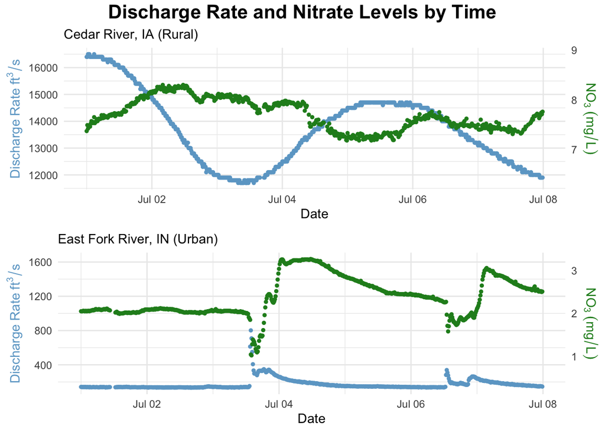

```r
# The ggplot code for the plot below was written by Georgia Akins, a member of my ecotopic group. She went above and beyond to create beautiful dual axis plots and gave the group permission to use her code for the individual report.

rural_IA_dischargeNO3_plot <- ggplot(USGS_IA_rural_combo, aes(x = newdate)) +
  geom_point(aes(y = discharge), colour = "skyblue3", size = 1) +
  geom_point(aes(y = nitrate * 1850), colour = "forestgreen", size = 1) +
  scale_y_continuous(
    name = expression(Discharge~Rate~ft^3/s),
    sec.axis = sec_axis(~ . / 1850, name = expression(NO[3]~(mg/L)))) +
  labs(x = "Date",
       subtitle = "Cedar River, IA (Rural)") +
  theme_minimal() +
  theme(axis.title.y = element_text(color = "skyblue3"),
        axis.title.y.right = element_text(color = "forestgreen"))

urban_IN_dischargeNO3_plot <- ggplot(USGS_IN_urban_combo, aes(x = newdate)) +
  geom_point(aes(y = discharge), colour = "skyblue3", size = 1) +
  geom_point(aes(y = nitrate * 500), colour = "forestgreen", size = 1) +
  scale_y_continuous(
    name = expression(Discharge~Rate~ft^3/s),
    sec.axis = sec_axis(~ . / 500, name = expression(NO[3]~(mg/L)))) +
  labs(x = "Date",
       subtitle = "East Fork River, IN (Urban)") +
  theme_minimal() +
  theme(axis.title.y = element_text(color = "skyblue3"),
        axis.title.y.right = element_text(color = "forestgreen"))

grid.arrange(rural_IA_dischargeNO3_plot, urban_IN_dischargeNO3_plot,
             nrow = 2,
             top = textGrob("Discharge Rate and Nitrate Levels by Time",
                            gp = gpar(fontsize = 16, fontface = "bold")))
```

This plot uses two y-axes to show the relationship between Discharge Rate (blue) and Nitrate Concentration(green) on the y-axes across time on the x-axis. The plot shows that when discharge rate increases, nitrate concentration decreases.

**Hypothesis ii.**

To test whether Dissolved Oxygen will decrease as discharge rate increases, the plot below shows the relationship between discharge rate and dissolved oxygen levels by time.

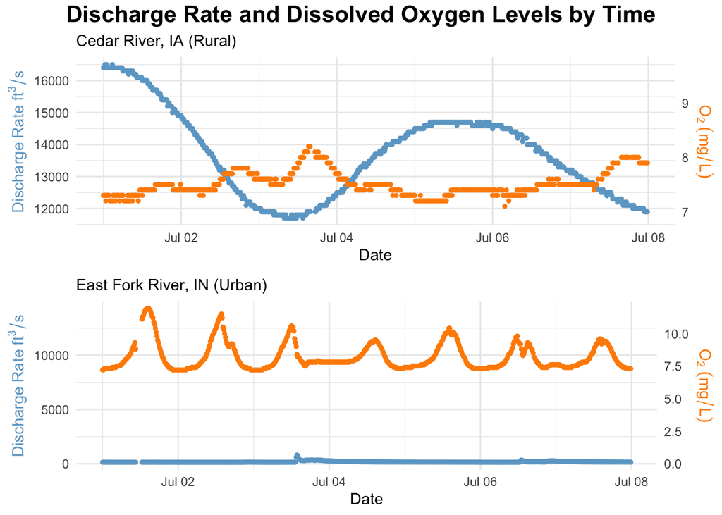

```r
rural_IA_dischargeDO_plot <- ggplot(USGS_IA_rural_combo, aes(x = newdate)) +
  geom_point(aes(y = discharge), colour = "skyblue3", size = 1) +
  geom_point(aes(y = DO * 1700), colour = "darkorange", size = 1) +
  scale_y_continuous(
    name = expression(Discharge~Rate~ft^3/s),
    sec.axis = sec_axis(~ . / 1700, name = expression(O[2]~(mg/L)))) +
  labs(x = "Date",
       subtitle = "Cedar River, IA (Rural)") +
  theme_minimal() +
  theme(axis.title.y = element_text(color = "skyblue3"),
        axis.title.y.right = element_text(color = "darkorange"))

urban_IN_dischargeDO_plot <- ggplot(USGS_IN_urban_combo, aes(x = newdate)) +
  geom_point(aes(y = discharge), colour = "skyblue3", size = 1) +
  geom_point(aes(y = DO * 1200), colour = "darkorange", size = 1) +
  scale_y_continuous(
    name = expression(Discharge~Rate~ft^3/s),
    sec.axis = sec_axis(~ . / 1200, name = expression(O[2]~(mg/L)))) +
  labs(x = "Date",
       subtitle = "East Fork River, IN (Urban)") +
  theme_minimal() +
  theme(axis.title.y = element_text(color = "skyblue3"),
        axis.title.y.right = element_text(color = "darkorange"))


grid.arrange(rural_IA_dischargeDO_plot, urban_IN_dischargeDO_plot,
             nrow = 2,
             top = textGrob("Discharge Rate and Dissolved Oxygen Levels by Time",
                            gp = gpar(fontsize = 16, fontface = "bold")))
```

This plot uses two y-axes to show the relationship between Discharge Rate (blue) and Dissolved Oxygen Levels (orange) on the y-axes across time on the x-axis. The plot shows that for the rural river, when discharge rate increases, dissolved oxygen decreases and for the urban river, discharge rate remains relatively constant while Dissolved Oxygen fluctuates with time of day.

**Hypothesis iii.**

To prove that discharge rate will be independent of time of day, the plot below shoes discharge rate by time for both the rural river (red) and the urban river (blue).

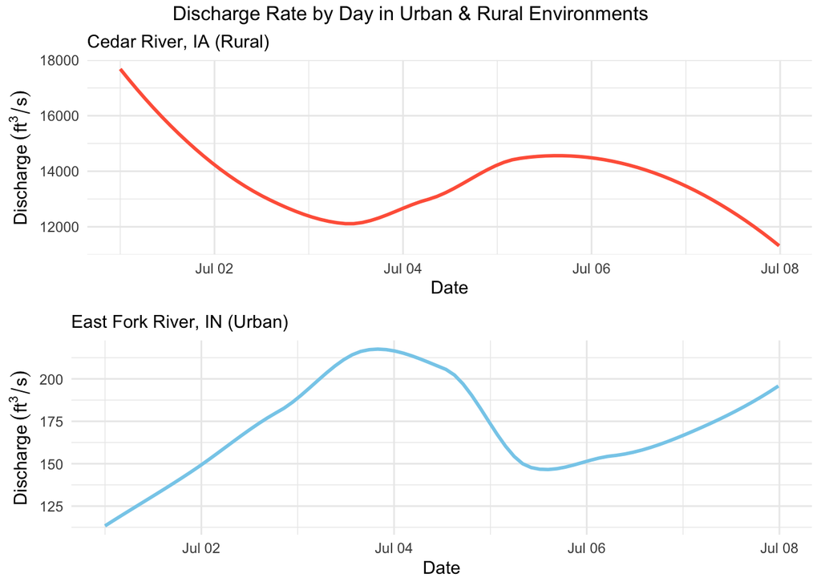

```r
rural_discharge_plot <- USGS_IA_rural_combo %>%
  ggplot(aes(x = newdate, y = discharge)) +
  geom_smooth(se = FALSE, colour = "tomato") +
  labs(x = "Date",
       y = expression(Discharge~(ft^3/s)),
       subtitle = "Cedar River, IA (Rural)") +
  theme_minimal()

urban_discharge_plot <- USGS_IN_urban_combo %>%
  ggplot(aes(x = newdate, y = discharge)) +
  geom_smooth(se = FALSE, colour = "skyblue") +
  labs(x = "Date",
       y = expression(Discharge~(ft^3/s)),
       subtitle = "East Fork River, IN (Urban)") +
  theme_minimal()

grid.arrange(rural_discharge_plot, urban_discharge_plot, nrow = 2, top = "Discharge Rate by Day in Urban & Rural Environments")
```

This plot shows discharge rate on the y-axis and date on the x-axis. Discharge rate does not fluctuate through patterns daily, but rather shows a general trend that persists over the span of the whole week. This shows that discharge rate is independent of time of day.

**Hypothesis iv.**

To show that Nitrate concentration will be independent of time of day the plot below visualizes nitrate concentration by time.

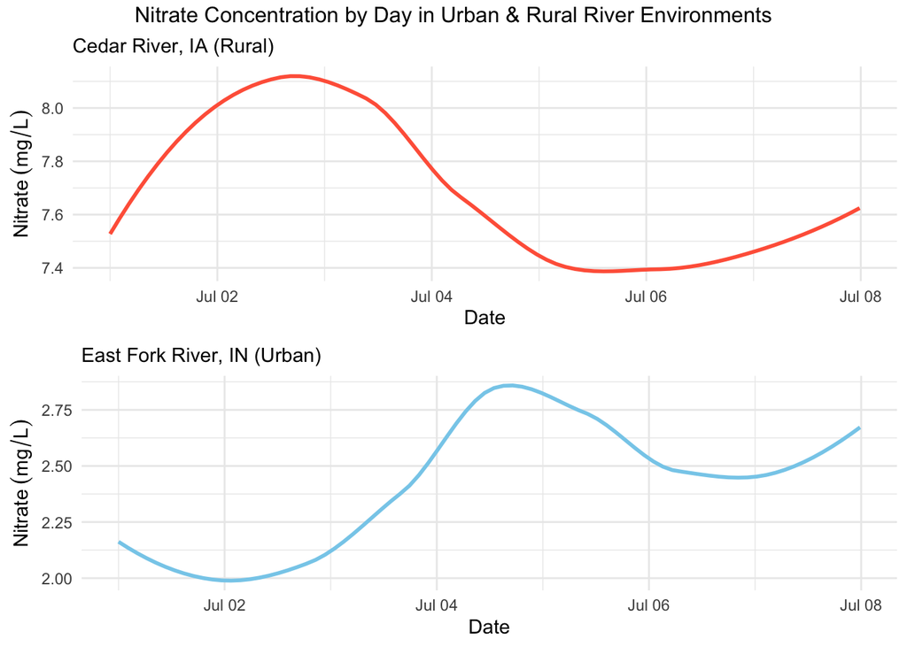

```r
rural_nitrate_plot <- USGS_IA_rural_combo %>%
  ggplot(aes(x = newdate, y = nitrate)) +
  geom_smooth(se = FALSE, colour = "tomato") +
  labs(x = "Date",
       y = expression(Nitrate~(mg/L)),
       subtitle = "Cedar River, IA (Rural)") +
  theme_minimal()

urban_nitrate_plot <- USGS_IN_urban_combo %>%
  ggplot(aes(x = newdate, y = nitrate)) +
  geom_smooth(se = FALSE, colour = "skyblue") +
  labs(x = "Date",
       y = expression(Nitrate~(mg/L)),
       subtitle = "East Fork River, IN (Urban)") +
  theme_minimal()

grid.arrange(rural_nitrate_plot, urban_nitrate_plot, nrow = 2, top = "Nitrate Concentration by Day in Urban & Rural River Environments")
```

This plot shows nitrate concentration on the y-axis and date on the x-axis. Nitrate levels across the week show a general trend that does not fluctuate daily proving that nitrate levels are not dependent on time of day.

**Hypothesis v.**

To assess whether dissolved oxygen will be dependent on time of day, a plot showing Dissolved Oxygen vs. time is given for both rural and urban rivers.

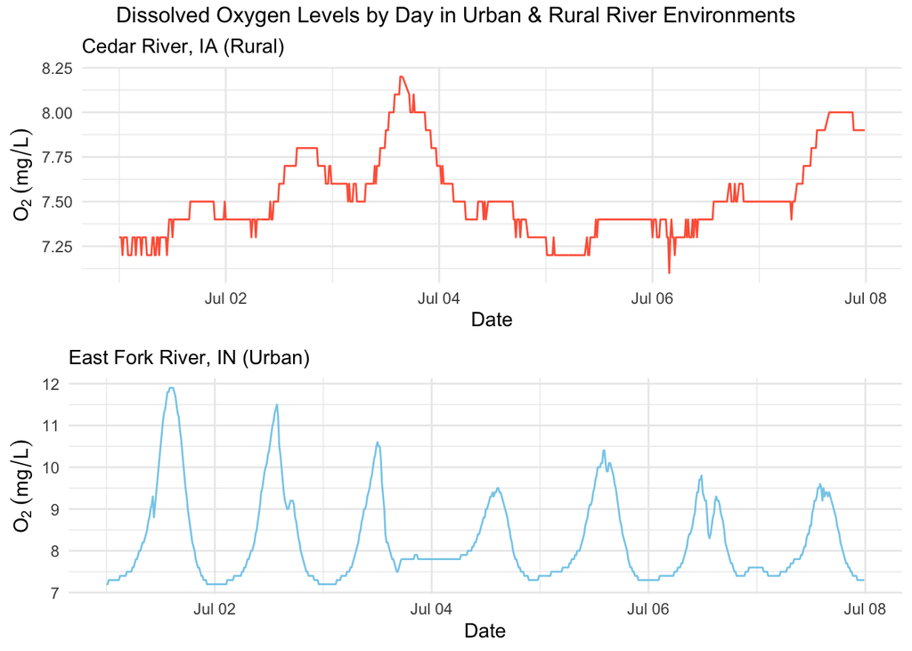

```r
rural_do_plot <- USGS_IA_rural_combo %>%
  ggplot(aes(x = newdate, y = DO)) +
  geom_line(se = FALSE, colour = "tomato") +
  labs(x = "Date",
       y = expression(O[2]~(mg/L)),
       subtitle = "Cedar River, IA (Rural)") +
  theme_minimal()

urban_do_plot <- USGS_IN_urban_combo %>%
  ggplot(aes(x = newdate, y = DO)) +
  geom_line(colour = "skyblue") +
  labs(x = "Date",
       y = expression(O[2]~(mg/L)),
       subtitle = "East Fork River, IN (Urban)") +
  theme_minimal()

grid.arrange(rural_do_plot, urban_do_plot, nrow = 2, top = "Dissolved Oxygen Levels by Day in Urban & Rural River Environments")
```

**Hypothesis vi.**

Dissolved Oxygen in urban land use settings will fluctuate more daily than in rural settings because rural settings are affected by less anthropogenic factors than urban settings.

```r
rural_do_daily <- USGS_IA_rural_combo %>%
  group_by(datetime) %>%
  summarise(rural_fluc = max(DO) - min(DO))

urban_do_daily <- USGS_IN_urban_combo %>%
  group_by(datetime) %>%
  summarise(urban_fluc = max(DO) - min(DO))

combined_USGS_data %>%
  group_by(datetime, urbanity) %>%
  summarise(fluctuation =  max(DO) - min(DO), .groups = "keep") %>%
  pivot_wider(names_from = urbanity, values_from = fluctuation) %>%
  summarise(DO_difference = urban - rural)
```

```
# A tibble: 7 × 2
  datetime   DO_difference
  <chr>              <dbl>
1 2019-07-01           4.4
2 2019-07-02           3.8
3 2019-07-03           2.7
4 2019-07-04           1.8
5 2019-07-05           2.9
6 2019-07-06           2
7 2019-07-07           1.7
```

**Statistical Tests**

```r
# Linear Models
## NO3 vs discharge
dischargeNO3_lm <- lm(nitrate ~ discharge, data = combined_USGS_data)
tidy(dischargeNO3_lm)
```

```
# A tibble: 2 × 5
  term        estimate  std.error statistic p.value
  <chr>          <dbl>      <dbl>     <dbl>   <dbl>
1 (Intercept) 2.38     0.0226          105.       0
2 discharge   0.000384 0.00000237      162.       0
```

```r
## DO vs discharge
dischargeDO_lm <- lm(DO ~ discharge, data = combined_USGS_data)
tidy(dischargeDO_lm)
```

```
# A tibble: 2 × 5
  term          estimate  std.error statistic  p.value
  <chr>            <dbl>      <dbl>     <dbl>    <dbl>
1 (Intercept)  8.24      0.0298         277.  0
2 discharge   -0.0000539 0.00000312     -17.3 2.99e-60
```

```r
## rural NO3 vs discharge
rural_dischargeNO3_lm <- lm(nitrate ~ discharge, data = USGS_IA_rural_combo)
tidy(rural_dischargeNO3_lm)
```

```
# A tibble: 2 × 5
  term          estimate  std.error statistic   p.value
  <chr>            <dbl>      <dbl>     <dbl>     <dbl>
1 (Intercept)  8.58      0.124          69.4  1.61e-291
2 discharge   -0.0000634 0.00000896     -7.08 3.97e- 12
```

```r
## rural DO vs discharge
rural_dischargeDO_lm <- lm(DO ~ discharge, data = USGS_IA_rural_combo)
tidy(rural_dischargeDO_lm)
```

```
# A tibble: 2 × 5
  term         estimate  std.error statistic   p.value
  <chr>           <dbl>      <dbl>     <dbl>     <dbl>
1 (Intercept)  9.25     0.0586         158.  0
2 discharge   -0.000126 0.00000424     -29.8 5.16e-121
```

```r
## urban NO3 vs discharge
urban_dischargeNO3_lm <- lm(nitrate ~ discharge, data = USGS_IN_urban_combo)
tidy(urban_dischargeNO3_lm)
```

```
# A tibble: 2 × 5
  term         estimate std.error statistic   p.value
  <chr>           <dbl>     <dbl>     <dbl>     <dbl>
1 (Intercept)  2.49      0.0524       47.6  5.13e-216
2 discharge   -0.000628  0.000288     -2.18 2.95e-  2
```

```r
## urban DO vs discharge
urban_dischargeDO_lm <- lm(DO ~ discharge, data = USGS_IN_urban_combo)
tidy(urban_dischargeDO_lm)
```

```
# A tibble: 2 × 5
  term        estimate std.error statistic   p.value
  <chr>          <dbl>     <dbl>     <dbl>     <dbl>
1 (Intercept)  8.54     0.118        72.2  2.38e-316
2 discharge   -0.00186  0.000649     -2.86 4.40e-  3
```

```r
# Combined effect
NO3_lm <- lm(nitrate ~ discharge + urbanity + DO, data = combined_USGS_data)
tidy(NO3_lm)
```

```
# A tibble: 4 × 5
  term            estimate std.error statistic   p.value
  <chr>              <dbl>     <dbl>     <dbl>     <dbl>
1 (Intercept)    8.92      0.210         42.6  8.02e-247
2 discharge     -0.0000692 0.0000118     -5.86 5.75e-  9
3 urbanityurban -6.24      0.160        -39.0  4.03e-219
4 DO            -0.0344    0.0145        -2.38 1.77e-  2
```

```r
# ANOVA tests
## discharge vs urbanity
discharge_ANOVA <- aov(discharge ~ urbanity, data = combined_USGS_data)
report(discharge_ANOVA)
```

```
The ANOVA (formula: discharge ~ urbanity) suggests that:

  - The main effect of urbanity is statistically significant and large (F(1,
1274) = 66023.09, p < .001; Eta2 = 0.98, 95% CI [0.98, 1.00])

Effect sizes were labelled following Field's (2013) recommendations.
```

```r
## NO3 vs urbanity
NO3_ANOVA <- aov(nitrate ~ urbanity, data = combined_USGS_data)
report(NO3_ANOVA)
```

```
The ANOVA (formula: nitrate ~ urbanity) suggests that:

  - The main effect of urbanity is statistically significant and large (F(1,
1274) = 57373.14, p < .001; Eta2 = 0.98, 95% CI [0.98, 1.00])

Effect sizes were labelled following Field's (2013) recommendations.
```

```r
## DO vs urbanity
DO_ANOVA <- aov(DO ~ urbanity, data = combined_USGS_data)
report(DO_ANOVA)
```

```
The ANOVA (formula: DO ~ urbanity) suggests that:

  - The main effect of urbanity is statistically significant and large (F(1,
1274) = 272.41, p < .001; Eta2 = 0.18, 95% CI [0.15, 1.00])

Effect sizes were labelled following Field's (2013) recommendations.
```

```r
# Combined effect
combined_effect_ANOVA <- aov(nitrate ~ discharge + urbanity + DO, data = combined_USGS_data)
report(combined_effect_ANOVA)
```

```
The ANOVA (formula: nitrate ~ discharge + urbanity + DO) suggests that:

  - The main effect of discharge is statistically significant and large (F(1,
1272) = 57444.62, p < .001; Eta2 (partial) = 0.98, 95% CI [0.98, 1.00])
  - The main effect of urbanity is statistically significant and large (F(1,
1272) = 1513.43, p < .001; Eta2 (partial) = 0.54, 95% CI [0.52, 1.00])
  - The main effect of DO is statistically significant and very small (F(1, 1272)
= 5.64, p = 0.018; Eta2 (partial) = 4.42e-03, 95% CI [4.05e-04, 1.00])

Effect sizes were labelled following Field's (2013) recommendations.
```

# Discussion

Understanding the relationship between discharge rate, nitrate concentration, dissolved oxygen, and urbanity in rivers is helpful to implementing river restoration action and assessing how land use impacts Nitrogen entering the water system. The visualizations in this project assess the visual trends of each hypothesis and are supported by statistically significant relationships shown in Linear Regressions and ANOVA tests. The first hypothesis was rejected because the visualization showed that nitrate concentration decreased as river discharge rate increased, following an inverse relationship. This result goes against prior knowledge of nutrient uptake length in rivers with higher discharge, but may be explained by the shallow depth of the river offering more area to uptake the nutrients. The next hypothesis was accepted as Dissolved Oxygen was seen to follow an inverse relationship with Discharge rate, when discharge rate increases, dissolved oxygen decreases. This result corresponds with previous literature that explains how a higher discharge rate makes it more difficult to take in oxygen from the atmosphere. The third and fourth hypotheses assessing independence of discharge rate and nitrogen concentration against time were accepted as true. This is justified by their trends fluctuating over the entire duration of the study week instead of cycling daily in relation to daily temperature, sunlight availability, or time of day. The fifth hypothesis was proven true in confirming the relationship between dissolved oxygen and time of day. This finding is logical because oxygen presence in the atmosphere fluctuates daily depending on photosynthesis, human activity, and land use. Finally, the sixth hypothesis proves that dissolved oxygen fluctuates more in the urban settings than in rural settings. This conclusion is reasonable because urban settings often have more external influences (including road runoff, sewer lines, and more) on river discharge than rural settings (Price et al.). It is important to note that the data used in this study was only taken over a one week period in July so these results should be interpreted with caution and cannot be generalized to all rivers. Despite this, applying the principle that land use has an effect on discharge rate, nitrogen concentration and dissolved oxygen levels in rivers, river ecosystem conservation action can be taken to decrease external sources of water contributing to discharge rates in urban rivers (Allen et al.). The next steps for this analysis would include collecting more data that has a longer study period, takes more streams into account, and examines more variables. It would also be helpful to include data from streams that are more closely related than the streams analyzed in this study to have a better basis for comparison. In summary, the findings from this analysis highlight the complex relationships between land use, discharge rate, nitrogen concentration, and dissolved oxygen in rivers, calling for more extensive research to guide effective nutrient cycling in waterways.

# Works Cited

Mueller Price Jennifer, Bledsoe Brian P., and Baker Daniel W. (2015), Influences of sudden changes in discharge and physical stream characteristics on transient storage and nitrate uptake in an urban stream, Hydrol. Process., 29, pages 1466–1479. doi: 10.1002/hyp.10275

Rosburg, Tyler T., Peter A. Nelson, and Brian P. Bledsoe, 2017. Effects of Urbanization on Flow Duration and Stream Flashiness: A Case Study of Puget Sound Streams, Western Washington, USA. Journal of the American Water Resources Association (JAWRA) 53(2): 493–507, DOI: 10.1111/1752-1688.12511

Allan, J. David. “Landscapes and riverscapes: the influence of land use on stream ecosystems.” Annu. Rev. Ecol. Evol. Syst. 35.1 (2004): 257-284. Cara J. Poor, Jeffrey J. McDonnell. The effects of land use on stream nitrate dynamics.Journal of Hydrology,Volume 332, Issues 1–2, 2007. https://doi.org/10.1016/j.jhydrol.2006.06.022.

Klose, K., Cooper, S. D., Leydecker, A. D., & Kreitler, J. (2012). Relationships among catchment land use and concentrations of nutrients, algae, and dissolved oxygen in a southern California river. Freshwater Science, 31(3), 908–927. https://doi.org/10.1899/11-155.1